# Curva de poder de testes para a hipótese de igualdade de variância

Alexandre Diaz (GRR20137526) Vinicius Souza (GRR20149129)

22 de novembro de 2017

## Resumo e Revisão de Literatura:

Esse trabalho consiste em comparar $\sigma^2_1$ e $\sigma^2_2$ de duas populações independentes, com 3 testes de comparação entre duas variâncias. Com isso vamos avaliar o poder dos 3 testes, que compara variâncias populacionais. Para isso usaremos duas populações, uma população com a variância fixa, e a outra não-fixa, para comparar essas duas populações com variâncias diferentes. Com os seguintes testes:

**Tete F para comparação de duas variâncias:** Executa um teste F para comparar as variâncias de duas amostras de populações normais.

**Mood Two-Sample Test of Scale:** Executa o teste de duas amostras da Mood para uma diferença nos parâmetros da escala. Com a média das duas populações comparadas tendo que ser iguais.

**Ansari-Bradley Test:** Executa o teste de duas amostras de Ansari-Bradley para uma diferença nos parâmetros da escala.

Os três testes podem ser usados para comparar duas variâncias. Para rodar eles usaremos as funções, **var.test**, **mood.test** e **ansari.test**. As três funções necessitam de dois vetores, nomeados de *x* e *y* para poder comparar as populações.

**Hipóteses Testadas**

Bilateral:
$$\left\{\begin{matrix}
Ho: \sigma^2_1=\sigma^2_2 & \\
Ha: \sigma^2_1\neq \sigma^2_2 &
\end{matrix}\right.$$

Unilateral:
$$\left\{\begin{matrix}
Ho: \sigma^2_1=\sigma^2_2 & \\
Ha: \sigma^2_1> \sigma^2_2 &
\end{matrix}\right.
\left\{\begin{matrix}
Ho: \sigma^2_1=\sigma^2_2 & \\
Ha: \sigma^2_1< \sigma^2_2 &
\end{matrix}\right.$$

H0: Não existem evidências significativa de diferença entre as variâncias. Ha: Existe evidência significativa de diferença entre as variâncias. Ou uma variância é maior que a outra.

Lembramos tambem que será observado o comportamento com diferentes tamanhos de amostras e 3 diferentes distribuições, a Normal, a Uniforme e a Poisson.

**Normal:** conhecida também como distribuição gaussiana, é a mais importante das distribuições contínuas. É uma distribuição parametrizada pela sua esperança ($\mu$) e desvio padrão ($\sigma$), logo X~N($\mu,\sigma^2$). Com a função densidade de probabilidade:

$$f(x)=\frac{1}{\sqrt{2\pi\sigma^2}}exp^{\left [ -\frac{1}{2}\left ( \frac{x-\mu}{\sigma} \right )^2 \right ]}, x\epsilon(-\infty ,\infty )$$

**Uniforme:** É a distribuição de probabilidades contínua mais simples de conceituar. É usada quando assumimos que as variáveis tem a mesma probabilidade de ocorrer. Seus parâmetros são a e b, e X~U(a,b) com a<b. Com a seguinte função densidade de probabilidade:

$$\left\{\begin{matrix}
\frac{1}{b-a}, &se \ a\leq x\leq b \\
0, & caso\ contrario
\end{matrix}\right.$$

**Poisson:** É uma distribuição de probabilidade com variável discreta que expressa a probabilidade de uma série de eventos ocorrer num certo período de tempo. A distribuição poisson tem parâmetro $\lambda$, com $\lambda>0$. Com a seguinte função de probabilidade:

$$P(X=x)=\frac{e^{-\lambda}\lambda^x}{x!}$$

Reforçando que nosso objetivo é avaliar o poder dos três testes citados para diferentes tamanhos de amostras, para 3 distribuições e com a primeira população com a variância fixada em 1, a segunda população tendo sua variância indo de 1 até 3. Ou seja, vamos fazer todas as possíveis combinações e avaliar seus respecitivos p-valores para tomar a decisão se rejeita ou não H0, com um nível de confiança de 95% ($\alpha=0.05$).

Vamos usar Monte Carlo, para replicar cada uma das combinações 5.000 vezes, e retornaremos a taxa de rejeição para cada combinação em relação aos 5.000 eventos ocorridos em cada combinação testada.

## Material e métodos:

Primeiramente vamos montar o nosso processo de simulação de **Monte Carlo** da seguinte maneira:

```r
simula0 <- function(n, sigma2b, dist, test) {
  pval <- replicate(5000, {                         # quantidade de vezes que irá repetir cada combinação (5.000)
    xy <- switch(dist,                              # criando números aleatórios das
                 norm = {                           # das distribuições escolhidas
                   x <- rnorm(n, 0, 1)              # (normal,uniforme e poisson)
                   y <- rnorm(n, 0, sqrt(sigma2b))  # precisou parametrizar a variância
                   list(x = x, y = y)
                 },
                 unif = {
                   x <- runif(n, min= -(sqrt(12 * 1) / 2), # parametrizando a e b
                              max = sqrt(12 * 1) / 2)
                   y <- runif(n,min= -(sqrt(12 * sigma2b) / 2),
                              max = sqrt(12 * sigma2b) / 2)
                   list(x = x, y = y)
                 },
                 pois = {
                   x <- rpois(n, 10) - 10
                   y <- rpois(n, 10*sigma2b) - 10 * sigma2b # como o teste de mood exige médias iguais, tivemos que aplicar essa parametrização
                   list(x = x, y = y)
                 })
    do.call(what = test, args = xy)$p.value                # entrando com os testes
  })
  pval<- na.omit(pval)
  sum(pval < 0.05)/length(pval)
}
```

**Exemplos:**

Amostra tamanho 10

variância = 1

var.test

e as 3 distribuições

```r
simula0(10,1,"norm","var.test") # percentual de rejeição para a normal
```

```
## [1] 0.0504
```

```r
simula0(10,1,"unif","var.test") # percentual de rejeição para a uniforme
```

```
## [1] 0.01
```

```r
simula0(10,1,"pois","var.test") # percentual de rejeição para a poisson.
```

```
## [1] 0.0546
```

**Tabela de todas as possíveis combinações**

```r
exper<- expand.grid(dist= c("norm", "unif", "pois"),
                    test= c("var.test","mood.test", "ansari.test"),
                    n= c(10,15,30,60,70),
                    sigma2b= c(1,1.2,1.4,1.6,1.8,2,2.2,2.4,2.6,2.7,2.8,3),
                    KEEP.OUT.ATTRS = FALSE,
                    stringsAsFactors = FALSE)

head(exper)
```

```
##   dist      test  n sigma2b
## 1 norm  var.test 10       1
## 2 unif  var.test 10       1
## 3 pois  var.test 10       1
## 4 norm mood.test 10       1
## 5 unif mood.test 10       1
## 6 pois mood.test 10       1
```

```r
str(exper)
```

```
## 'data.frame':    540 obs. of  4 variables:
##  $ dist   : chr  "norm" "unif" "pois" "norm" ...
##  $ test   : chr  "var.test" "var.test" "var.test" "mood.test" ...
##  $ n      : num  10 10 10 10 10 10 10 10 10 15 ...
##  $ sigma2b: num  1 1 1 1 1 1 1 1 1 1 ...
```

Foram geradas 540 combinações entre os tipos de teste, distribuição, tamanho de amostra e variância.

**Calculando o percentual de rejeição de todas as possíveis combinações**

```r
rej<- mapply(FUN = simula0,
           dist = exper$dist,
           test = exper$test,
           n = exper$n,
           sigma2b = exper$sigma2b)
## summary(rej)
dados<- data.frame(exper,rej)
```

## Resultados

```r
head(dados,20) # 20 primeiras linhas
```

```
##    dist        test  n sigma2b    rej
## 1  norm    var.test 10       1 0.0492
## 2  unif    var.test 10       1 0.0122
## 3  pois    var.test 10       1 0.0580
## 4  norm   mood.test 10       1 0.0462
## 5  unif   mood.test 10       1 0.0494
## 6  pois   mood.test 10       1 0.0692
## 7  norm ansari.test 10       1 0.0380
## 8  unif ansari.test 10       1 0.0394
## 9  pois ansari.test 10       1 0.0460
## 10 norm    var.test 15       1 0.0528
## 11 unif    var.test 15       1 0.0082
## 12 pois    var.test 15       1 0.0550
## 13 norm   mood.test 15       1 0.0486
## 14 unif   mood.test 15       1 0.0456
## 15 pois   mood.test 15       1 0.0660
## 16 norm ansari.test 15       1 0.0496
## 17 unif ansari.test 15       1 0.0502
## 18 pois ansari.test 15       1 0.0398
## 19 norm    var.test 30       1 0.0460
## 20 unif    var.test 30       1 0.0032
```

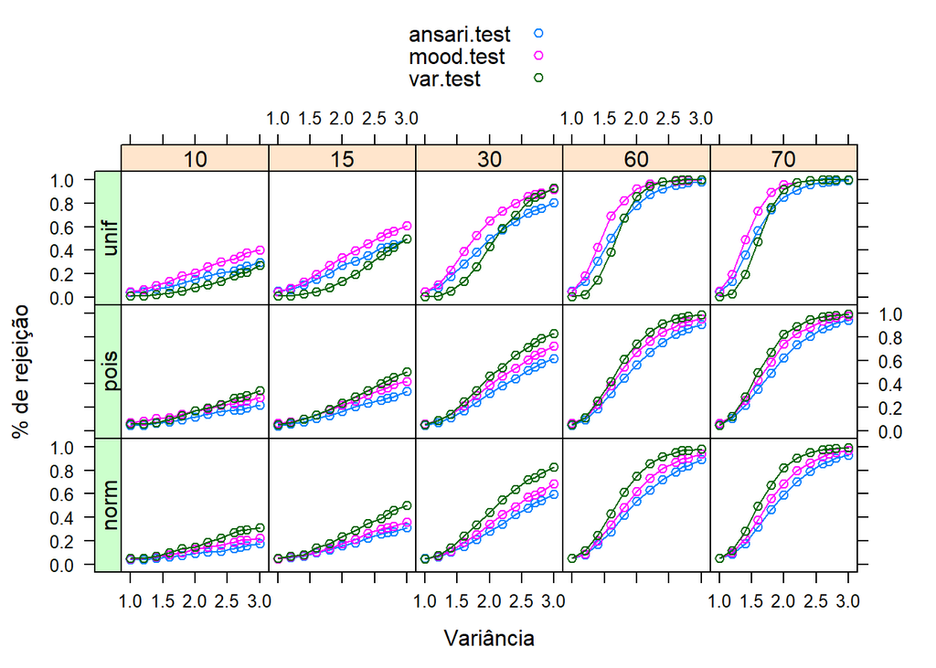

```r
library(latticeExtra)

useOuterStrips(
  xyplot(rej ~ sigma2b | factor(n) + dist,
         groups = test,
         data = dados,
         type = "o",
         auto.key = TRUE,
         xlab= "Variância",
         ylab= "% de rejeição"))
```

## Conclusões

Para a distribuição Uniforme aparentemente o teste Mood tem maior poder para detectar a diferença de variância de duas amostras, independente do tamanho da amostra.

Para a distribuição Normal e Poisson, vemos que o test F (var.test) tem maior poder para detectar a diferença de variância de duas amostras, independente do tamanho da amostra.

## Referências

Teste para comparação de duas variâncias. Disponível em :

http://www.portalaction.com.br/inferencia/56-teste-para-comparacao-de-duas-variancias-teste-f

Distribuição Normal. Disponível em:

http://www.portalaction.com.br/probabilidades/62-distribuicao-normal

https://pt.wikipedia.org/wiki/Distribui%C3%A7%C3%A3o_normal

Distribuição Uniforme. Disponível em:

http://www.portalaction.com.br/probabilidades/61-distribuicao-uniforme

https://pt.wikipedia.org/wiki/Distribuição_uniforme

Distribuição Poisson. Disponível em:

http://www.portalaction.com.br/probabilidades/52-distribuicao-de-poisson

https://pt.wikipedia.org/wiki/Distribui%C3%A7%C3%A3o_de_Poisson

Professor Doutor Walmes Marques Zeviani. Disponível em:

https://gitlab.c3sl.ufpr.br/walmes